# Exercises lecture 1

André Waage Rivenæs

29 9 2019

# Data import og vasking

1. Les inn Excel-filen “untidy_cashflow.xlsx” med hjelp av read_xlsx. Husk å spesifisere hvilke celler dere vil lese fra! Bruk: library(readxl). For hjelp skriv ?read_xlsx.

Husk å legge excel-filen i samme område hvor dere har opprettet RStudio-prosjektet. Dette tillater at du kan lese inn filen ved å skrive kun navnet på filen, istedenfor å måtte angi hele stien.

Merk at all kode skrives i de grå feltene under.

```r
df <- read_xlsx("data/untidy_cashflow.xlsx", range = "E8:J11")

#df <- read_xlsx(here::here("data/untidy_cashflow.xlsx", range = "E8:J11"))
```

2. Gjør dataen tidy ved hjelp av pivot_wider og/eller pivot_longer. Husk reglene:
- hver variabel er en kolonne
- hver observasjon er en rad
- i en tabell er det kun en type “observasjonsenhet”

PS: Det er her (minst) to mulige løsninger. Den ene er best for plotting, mens den andre er mer tidy og egnet for modellering o.l.

```r
# Option 1 ----------------------------------------------------------------

tidy_df <- df %>%
  pivot_longer(- År, values_to = "value", names_to = "year") %>%
  rename(type = År) %>%
  mutate(year = as.integer(year))

tidy_df
```

```
## # A tibble: 15 x 3
##    type      year value
##    <chr>    <int> <dbl>
##  1 Inntekt      1   300
##  2 Inntekt      2   250
##  3 Inntekt      3   300
##  4 Inntekt      4   150
##  5 Inntekt      5   200
##  6 Kostnad      1   120
##  7 Kostnad      2   300
##  8 Kostnad      3    50
##  9 Kostnad      4   200
## 10 Kostnad      5   100
## 11 Resultat     1   180
## 12 Resultat     2   -50
## 13 Resultat     3   250
## 14 Resultat     4   -50
## 15 Resultat     5   100
```

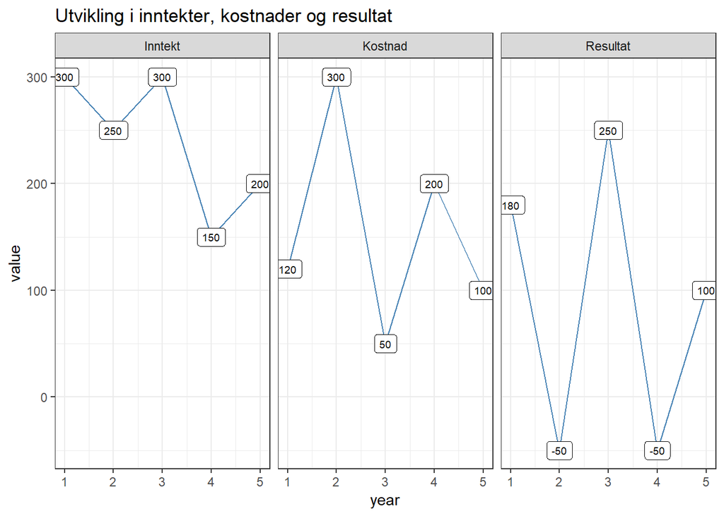

```r
# Man kan nå gjøre analyser slik som:
ggplot(tidy_df, aes(x = year, y = value)) +
  geom_line(color = "steelblue") +
  geom_point() +
  labs(title = "Utvikling i inntekter, kostnader og resultat") +
  geom_label(aes(label = value), size = 2.5) +
  theme_bw() +
  facet_wrap(~type)
```

```r
# Option 2 ----------------------------------------------------------------

tidy_df2 <- tidy_df %>%
  pivot_wider(names_from = type, values_from = value)

tidy_df2
```

```
## # A tibble: 5 x 4
##    year Inntekt Kostnad Resultat
##   <int>   <dbl>   <dbl>    <dbl>
## 1     1     300     120      180
## 2     2     250     300      -50
## 3     3     300      50      250
## 4     4     150     200      -50
## 5     5     200     100      100
```

```r
# Dette dataformatet er f.eks. enklere for modellering
lm(Resultat ~ Inntekt + Kostnad, data = tidy_df2)
```

```
##
## Call:
## lm(formula = Resultat ~ Inntekt + Kostnad, data = tidy_df2)
##
## Coefficients:
## (Intercept)      Inntekt      Kostnad
##  -5.084e-14    1.000e+00   -1.000e+00
```

```r
# For plotting i ggplot er det ofte en fordel å ha dataen i format 1,
# mens for mange andre formål (modellering o.l) er ofte format 2 bedre
```

# Datatransformasjon

## Filtrering og seleksjon

1. Fjern sykkelturer som endte i “workshop” eller “UIP”. Disse er ikke vanlige stasjoner. Bruk funksjonen “filter” fra dplyr.
2. Fjern sykkelturer med varighet lenger enn 3600 sekunder.
3. Lag en ny dataframe kalt dates_only hvor du kun velger kolonnene started_at og ended_at.

```r
df <- df %>%
  filter(!(end_station_name %in% c("workshop", "UIP"))) %>%
  filter(duration < 3600) %>%
  filter(start_station_name != end_station_name)

dates_only <- df %>%
  select(started_at, ended_at)
```

## Mutate

Legg til følgende variabler i df ved å bruke mutate:

```r
df <- df %>% mutate(
  duration_minutes = duration %/% 60,
  month = month(started_at),
  wday = wday(started_at),
  time_of_day_started = hour(started_at),
  is_weekend = wday %in% c(6, 7))
```

## Gruppering og summarise

1. Grupper etter ukedag. Hvilken ukedag har flest sykkelturer? Bruk group_by + summarise og tellefunksjonen n().
2. Grupper etter endestasjon. Hvilken endestasjon har de lengste turene i snitt? Sorter resultatet etter gjennomsnittlig durasjon ved å bruke arrange.

```r
# a
df %>%
  group_by(wday) %>%
  summarise(n = n())
```

```
## # A tibble: 7 x 2
##    wday     n
##   <dbl> <int>
## 1     1  8782
## 2     2 16078
## 3     3 16704
## 4     4 15690
## 5     5 15575
## 6     6 15086
## 7     7  9834
```

```r
# b
df %>%
  group_by(end_station_name) %>%
  summarise(snitt_duration = mean(duration)) %>%
  arrange(-snitt_duration)
```

```
## # A tibble: 38 x 2
##    end_station_name                snitt_duration
##    <chr>                                    <dbl>
##  1 Haukeland sykehus                        1266.
##  2 Høyskolen på Vestlandet                  1230.
##  3 Media Bergen                             1156.
##  4 Sandviken Brygge                         1076.
##  5 Høgskulen på Vestlandet                  1027.
##  6 Sandvikstorget                           1002.
##  7 Klostertet                                965.
##  8 Den nationale scene 1                     909.
##  9 Studentboligene ved Grønneviken           841.
## 10 Sandviksbodene                            831.
## # ... with 28 more rows
```

# Visualisering

```r
df_mdp <- df %>%
  filter(start_station_name == "Møllendalsplass")
```

## Scatter plots

Bruk det mindre datasettet df_mdp (generert i kodesnutten over) for oppgavene under.

### a) Visualiser sammenhengen mellom durasjon og lengde på tur med et scatter plot

Hint: Bruk geom_point

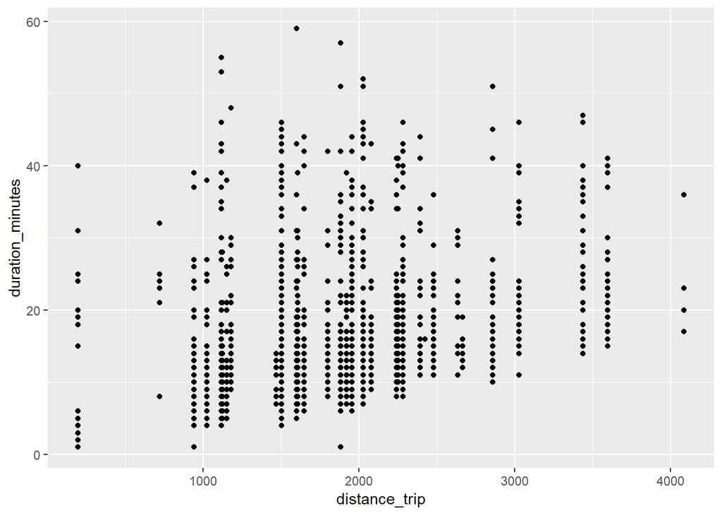

```r
p <- ggplot(df_mdp, aes(x = distance_trip, y = duration_minutes))

p +
  geom_point()
```

### b) Samme som i a), men bruk geom_jitter i stedet for geom_point

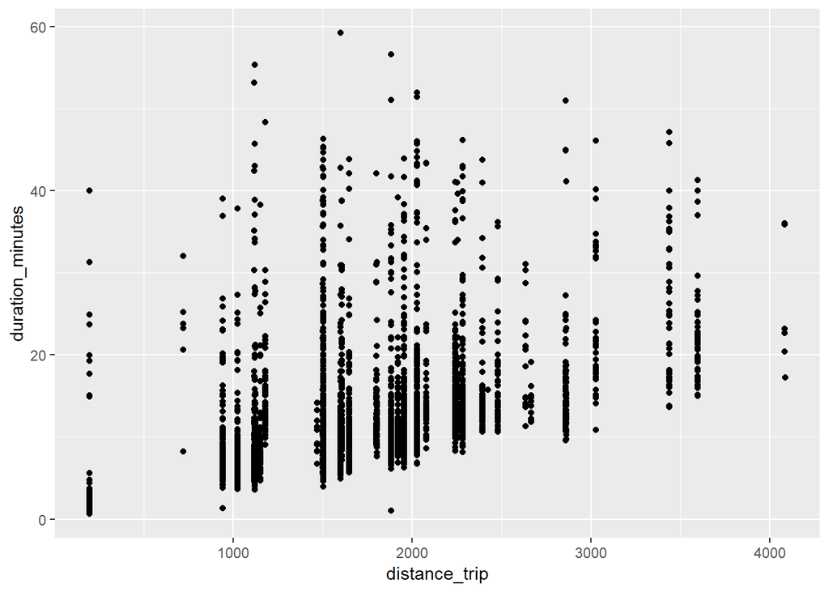

```r
p +
  geom_jitter()
```

### c) Legg til farge og transparens

Hint: geom-funksjonene tar inn argumenter. alpha = [et tall mellom 0 og 1] og color = “[navn på en farge]” styrer transparens og farge på punkter.

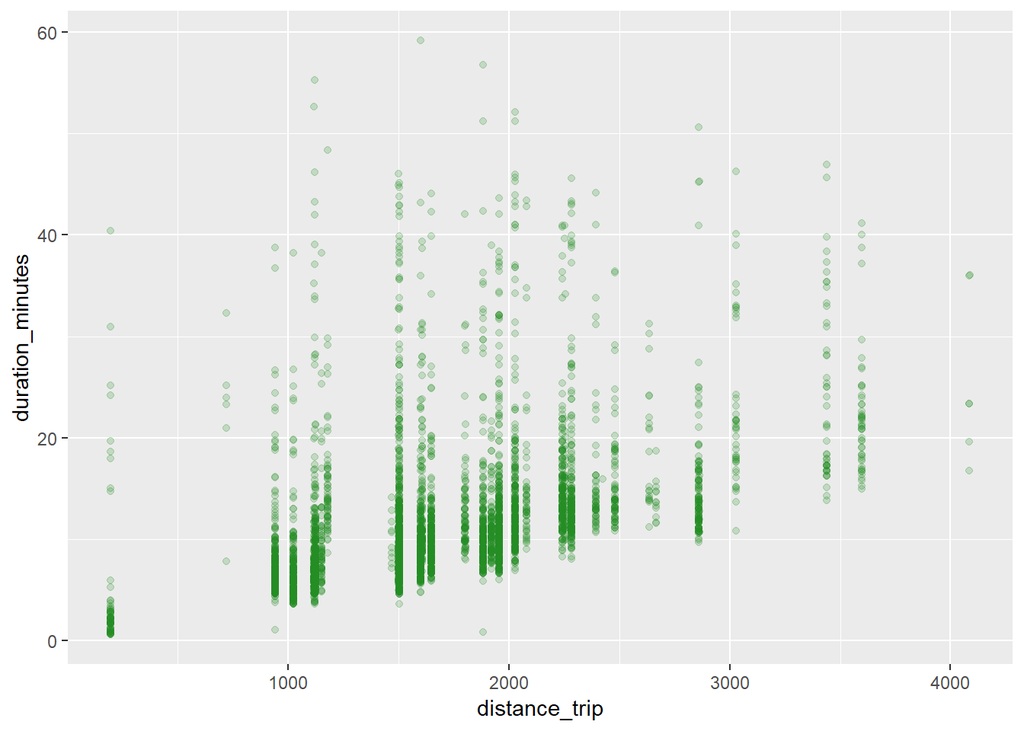

```r
p +
  geom_jitter(alpha = .2, color = "forestgreen")
```

Bruk ylim(). Argumentet til ylim er en vektor med laveste grense som første element og øvre grense som andre element.En vektor lages med funksjonen c().

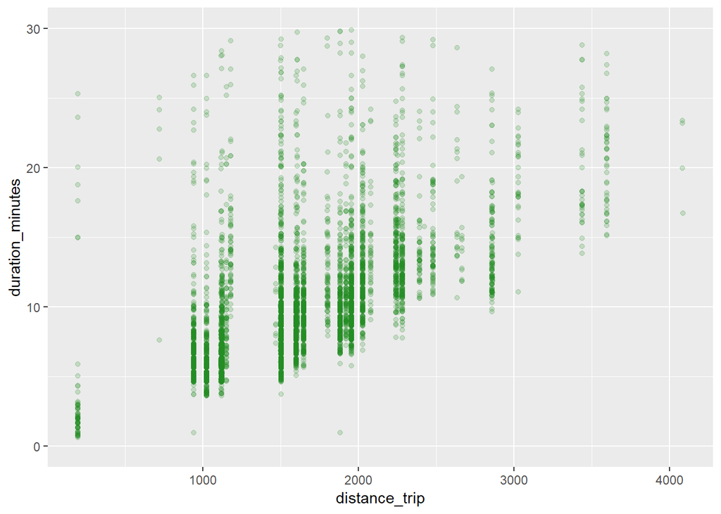

```r
p +
  geom_jitter(alpha = .2, color = "forestgreen") +
  ylim(c(0, 30))
```

### e) Legg til farger til punktene for å visualisere hvilket tidspunkt på døgnet turen ble gjennomført

Hint: color er også et argument til aes()-funksjonen. Sett color = tidspunkt_tur_startet, og ggplot vil på magisk vis mappe farge til tidspunkt. Ser du noe interessant?

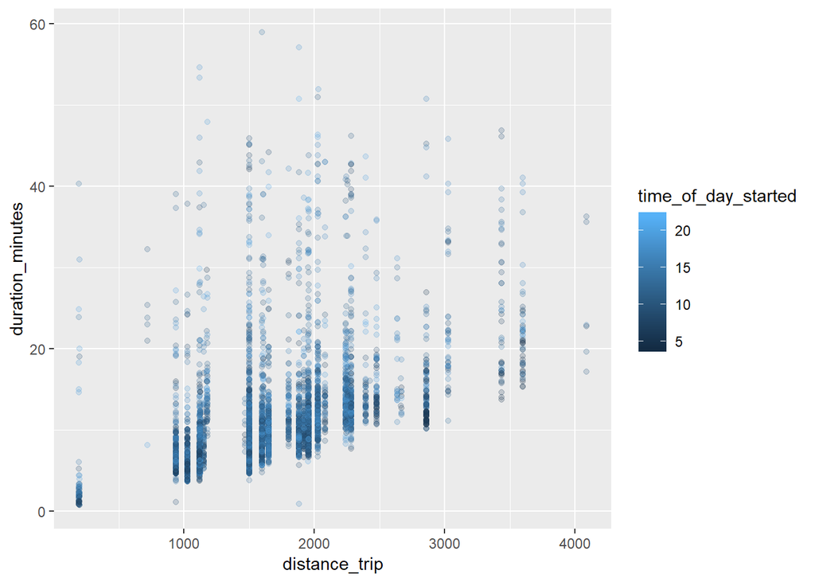

```r
ggplot(df_mdp, aes(x = distance_trip, y = duration_minutes, color = time_of_day_started)) +
  geom_jitter(alpha = .2)
```

### f) Legg til en trendlinje til plottet i c)

Use geom_smooth

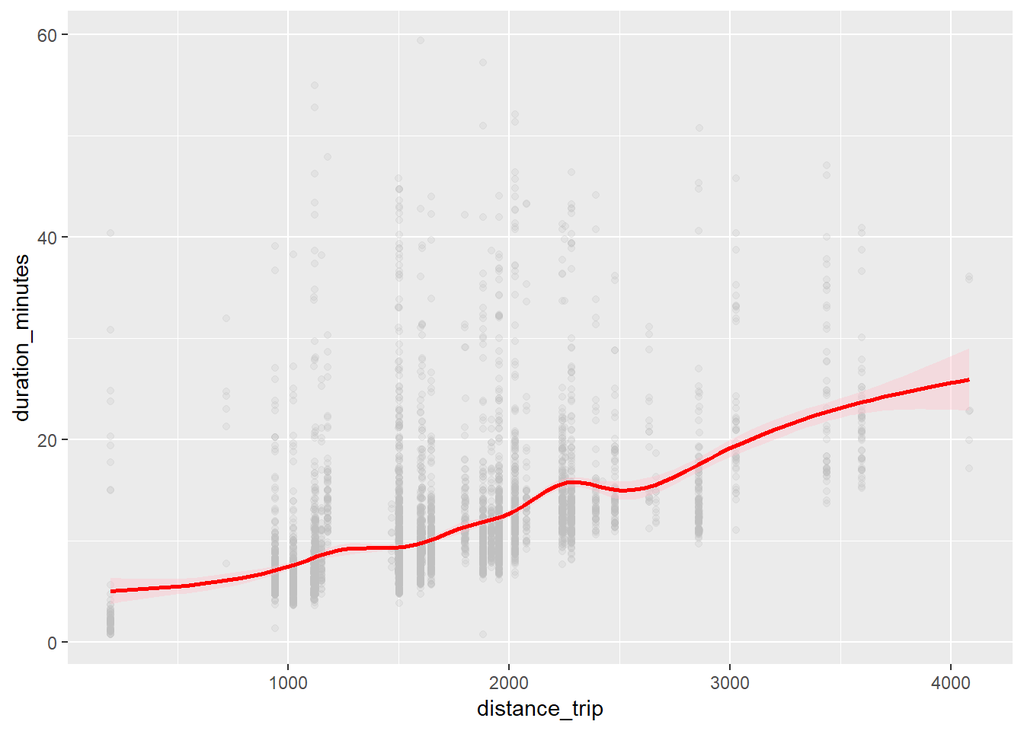

```r
p +
  geom_jitter(alpha = .2, color = "grey") +
  geom_smooth(color = "red", fill = "pink")
```

## Histogrammer

Bruk hele datasettet (df) for denne delen.

### a) Bruk et histogram for å visualisere distribusjonen til tidspunktet på dagen hvor turer starter

Bruk geom_histogram

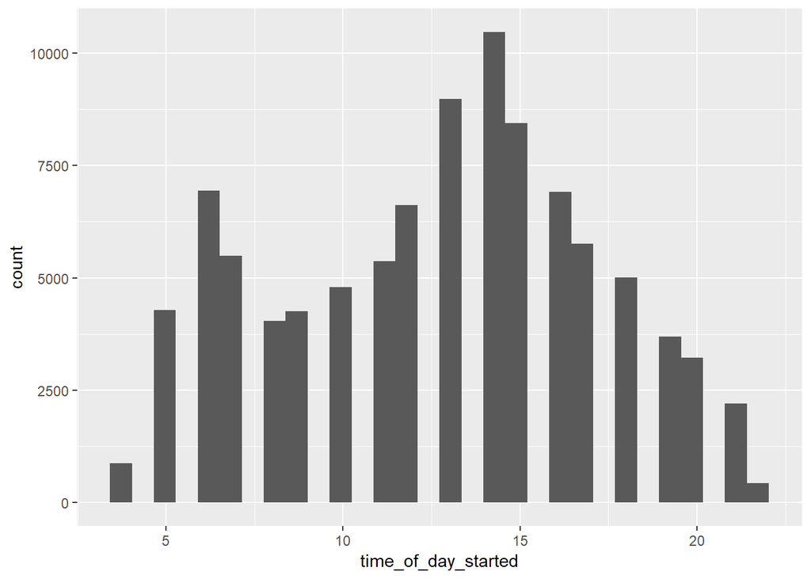

```r
p <- ggplot(df, aes(time_of_day_started))

p + geom_histogram()
```

### b) Som i a), men la hver bin representere en time

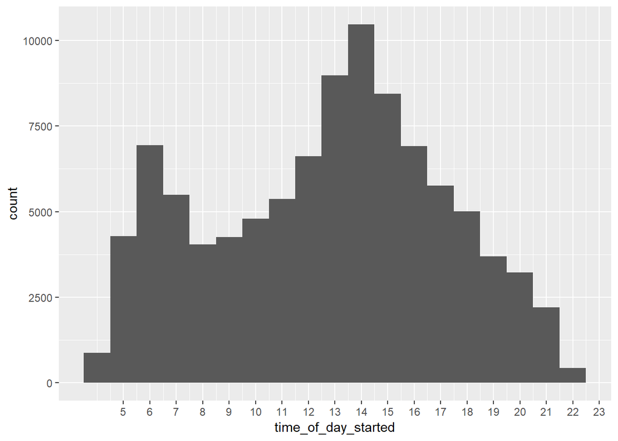

```r
p +
  geom_histogram(bins = 19) +
  scale_x_continuous(breaks = c(5:24))
```

### c) Legg til en farge til plottet i b)

Prøv “cornflowerblue”, “coral2” eller “forestgreen”. Forsøk å erstatte color-argumentet med fill.

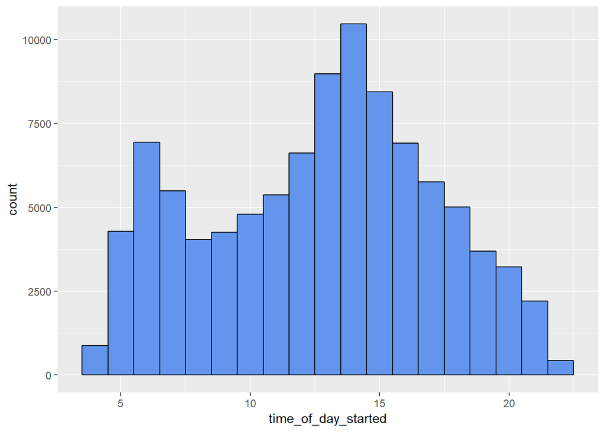

```r
p +
  geom_histogram(bins = 19, fill = "cornflowerblue", color = "black")
```

## Density plots

### a) Lag et density plot som visualiserer distribusjonen til turenes varighet

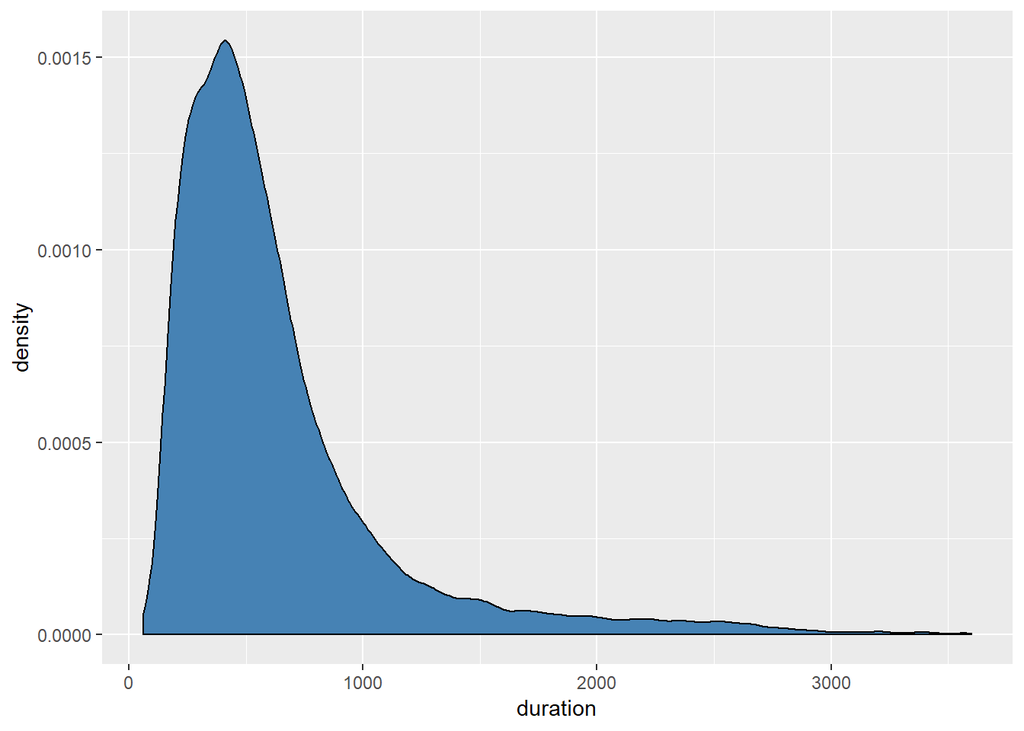

```r
ggplot(df, aes(duration)) +
  geom_density(fill = "steelblue")
```